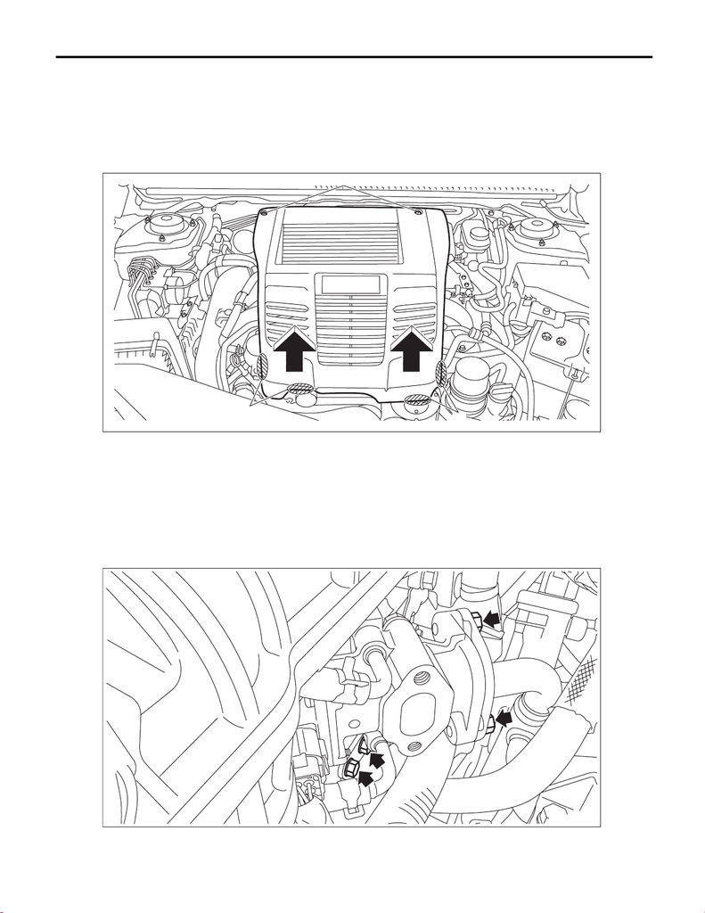

EC(w/o STI)-35

EGR Control Valve

EMISSION CONTROL (AUX. EMISSION CONTROL DEVICES)

7. EGR Control Valve

A: REMOVAL

1) Remove the collector cover.

(1) Remove the clips (A).

(2) Hold the shaded area (B) by hand and carefully pull the RH side (C) upward.

(3) Hold the shaded area (D) by hand and carefully pull the LH side (E) upward.

2) Disconnect the ground terminal from battery sensor. <Ref. to NT-5, BATTERY, NOTE, Note.>

3) Lift up the vehicle.

4) Remove the under cover. <Ref. to EI-21, REMOVAL, Front Under Cover.>

5) Drain approximately 3.0 L (3.2 US qt, 2.6 Imp qt) of coolant. <Ref. to CO(w/o STI)-13, DRAINING OF EN-

GINE COOLANT, REPLACEMENT, Engine Coolant.>

6) Remove the intercooler. <Ref. to IN(w/o STI)-38, REMOVAL, Intercooler.>

7) Remove the EGR pipe. <Ref. to EC(w/o STI)-32, REMOVAL, EGR Pipe.>

8) Remove the bolts which secure the EGR cooler to the EGR control valve, and remove the bolts which se-

cure the EGR control valve bracket A to the EGR control valve bracket B.

EX-03204

(A)

(B)

(C)

(E)

(D)

EC-03246

15WRX_STI_US_EN.book 35 ページ ２０１５年２月１３日 金曜日 午前１１時２０分

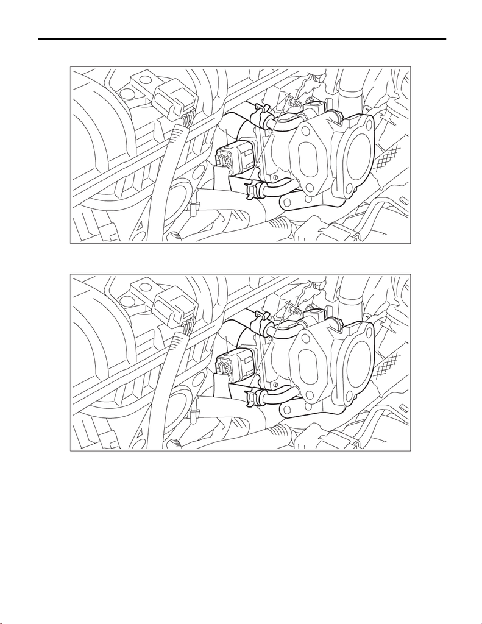

EC(w/o STI)-36

EGR Control Valve

EMISSION CONTROL (AUX. EMISSION CONTROL DEVICES)

9) Disconnect the connector (A) and preheater hose (B) from EGR control valve, and remove the EGR con-

trol valve.

B: INSTALLATION

1) Connect the preheater hose (B) and connector (A) to the EGR control valve.

EC-03247

(B)

(A)

EC-03247

(B)

(A)

15WRX_STI_US_EN.book 36 ページ ２０１５年２月１３日 金曜日 午前１１時２０分

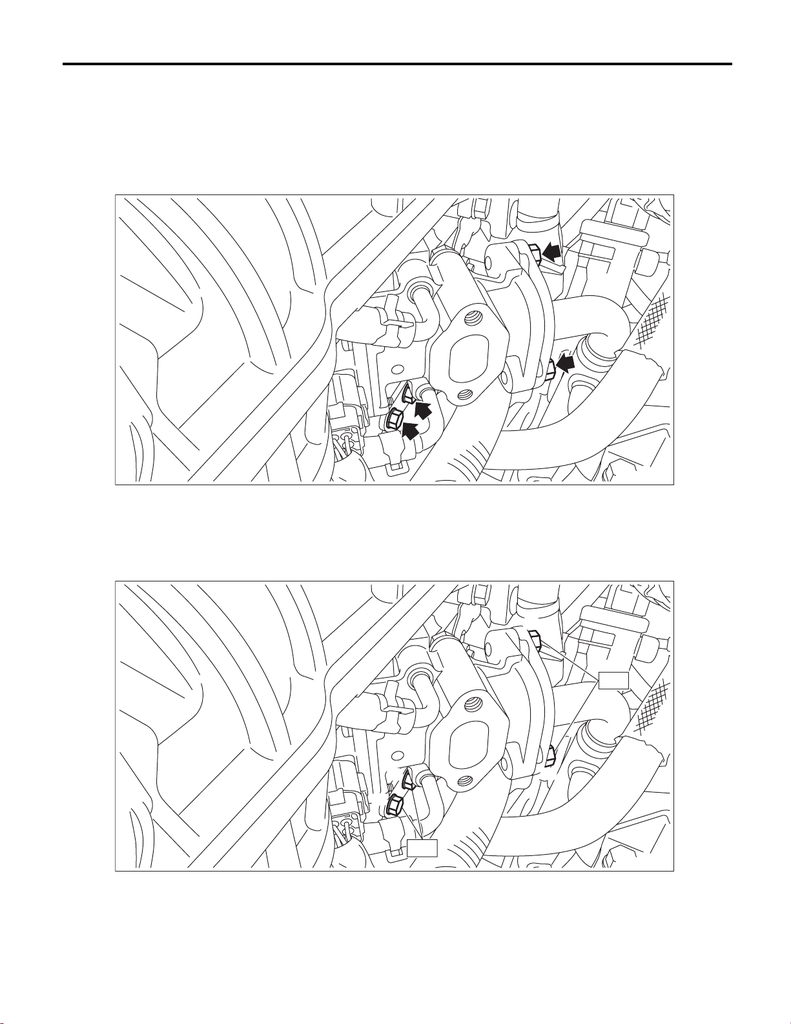

EC(w/o STI)-37

EGR Control Valve

EMISSION CONTROL (AUX. EMISSION CONTROL DEVICES)

2) Install the EGR control valve and EGR control valve bracket A to the EGR cooler and EGR control valve

bracket B.

(1) Set the EGR control valve and EGR control valve bracket A to the EGR cooler and EGR control valve

bracket B, and temporarily tighten the bolts which secure the EGR control valve and EGR control valve

bracket A to the EGR cooler and EGR control valve bracket B.

NOTE:

Use a new gasket.

(2) Tighten the bolts which secure the EGR control valve and EGR control valve bracket A to the EGR

cooler and EGR control valve bracket B in numerical order as shown in the figure.

Tightening torque:

T1: 6.4 N·m (0.7 kgf-m, 4.7 ft-lb)

T2: 19 N·m (1.9 kgf-m, 14.0 ft-lb)

3) Install the EGR pipe. <Ref. to EC(w/o STI)-33, INSTALLATION, EGR Pipe.>

4) Install the intercooler. <Ref. to IN(w/o STI)-41, INSTALLATION, Intercooler.>

5) Lift up the vehicle.

6) Install the under cover. <Ref. to EI-22, INSTALLATION, Front Under Cover.>

7) Lower the vehicle.

EC-03246

EC-03248

T1

(4)

(3)

T2

(1)

(2)

15WRX_STI_US_EN.book 37 ページ ２０１５年２月１３日 金曜日 午前１１時２０分

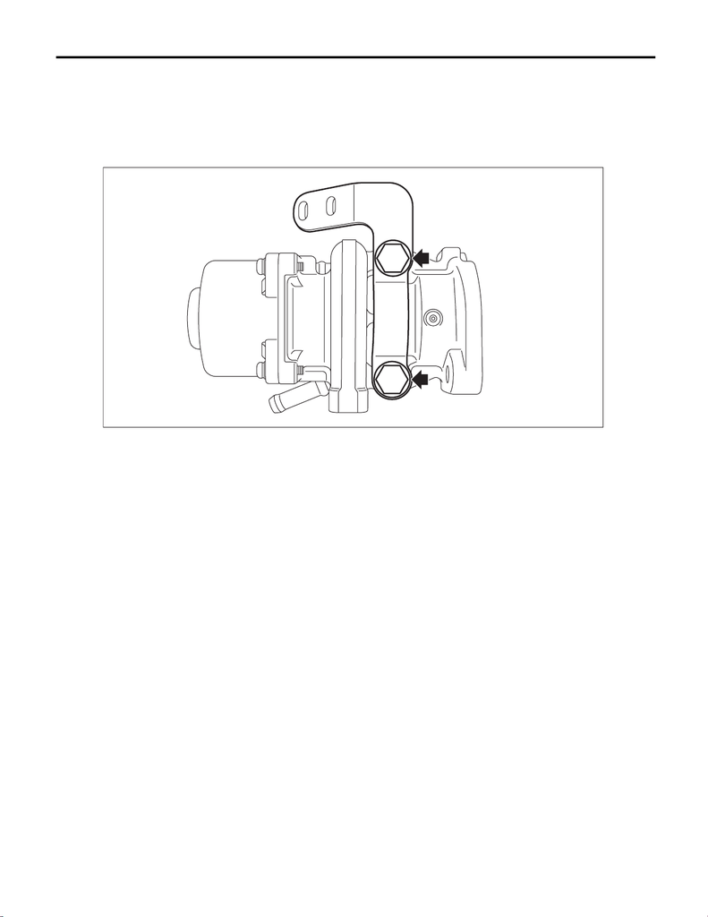

EC(w/o STI)-38

EGR Control Valve

EMISSION CONTROL (AUX. EMISSION CONTROL DEVICES)

8) Connect the ground terminal to battery sensor. <Ref. to NT-5, BATTERY, NOTE, Note.>

9) Fill engine coolant. <Ref. to CO(w/o STI)-14, FILLING OF ENGINE COOLANT, REPLACEMENT, Engine

Coolant.>

10) Install the collector cover.

C: DISASSEMBLY

Remove the EGR control valve bracket A from the EGR control valve.

D: ASSEMBLY

Assemble in the reverse order of disassembly.

Tightening torque:

19 N·m (1.9 kgf-m, 14.0 ft-lb)

EC-03138

15WRX_STI_US_EN.book 38 ページ ２０１５年２月１３日 金曜日 午前１１時２０分

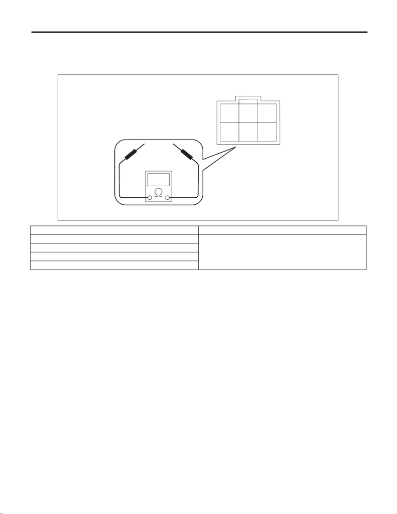

EC(w/o STI)-39

EGR Control Valve

EMISSION CONTROL (AUX. EMISSION CONTROL DEVICES)

E: INSPECTION

1) Check that the EGR control valve and EGR control valve bracket A have no deformation, cracks or other

damages.

2) Measure the resistance between EGR control valve terminals.

Terminal No. Standard

2 and 1

15±2 Ω (20°C (68°F))

2 and 3

5 and 4

5 and 6

EC-02819

31

654

2

15WRX_STI_US_EN.book 39 ページ ２０１５年２月１３日 金曜日 午前１１時２０分